# Одуванчик

## 4. Анализ данных

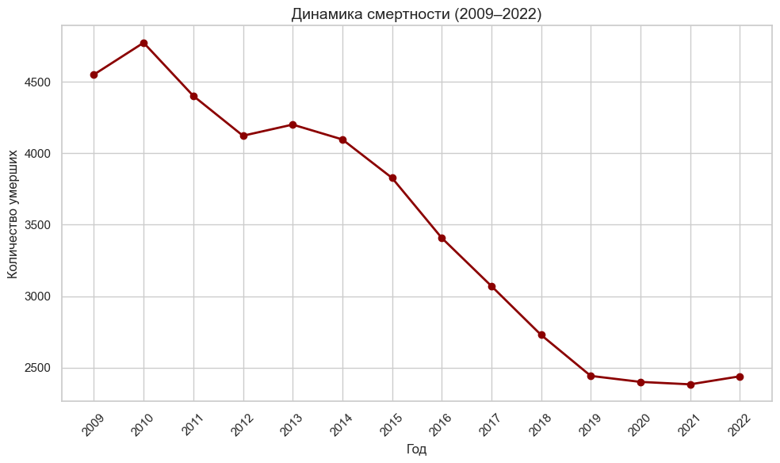

```
Корреляция между годом и смертностью: -0.972 (p-value: 0.00000)
```

```python
df_filtered = data[data['indicator_name'].str.strip().str.lower() == 'умерло, всего']

df_filtered = df_filtered.sort_values(by='year')

plt.figure(figsize=(10, 6))
plt.plot(df_filtered['year'], df_filtered['indicator_value'],
         marker='o', linestyle='-', color='darkred', linewidth=2)

plt.title("Динамика смертности (2009–2022)", fontsize=14)
plt.xlabel("Год", fontsize=12)
plt.ylabel("Количество умерших", fontsize=12)
plt.grid(True)
plt.xticks(df_filtered['year'], rotation=45)

plt.tight_layout()
plt.savefig('graphs/DEATH.png', dpi=600, bbox_inches='tight')
plt.show()

corr, p_value = stats.pearsonr(total_deaths['year'], total_deaths['indicator_value'])
print(f'Корреляция между годом и смертностью: {corr:.3f} (p-value: {p_value:.5f})')
```

Вывод: За рассматриваемый период наблюдается устойчивое снижение абсолютного числа умерших в УИС с 4551 человека в 2009 году до 2439 человек в 2022 году, что составляет снижение примерно на 46,4%.

1. С 2009 по 2013 год показатель колебался на уровне около 4000–4500 умерших, при этом наблюдалось незначительное снижение с 4551 в 2009 до 4097 в 2014 году.
2. С 2014 года тенденция стала более выраженно нисходящей, с ежегодным уменьшением смертности, вплоть до минимума в 2383 умерших в 2021 году.
3. В 2022 году наблюдается незначительный рост количества умерших — до 2439 человек, что может свидетельствовать о стабилизации или временной остановке тренда на снижение.

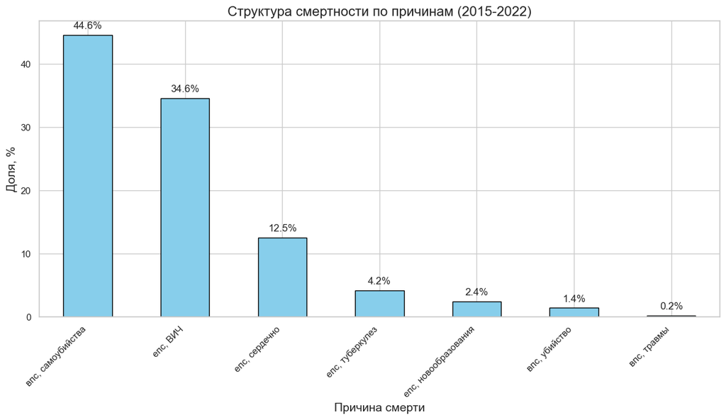

```python
exclude_causes = ['епс, болезни']

filtered_data = causes[
    (causes['year'] >= 2015) &
    (~causes['cause'].isin(exclude_causes))
]

cause_dist = filtered_data.groupby('cause')['indicator_value'].sum()
cause_percent = (cause_dist / cause_dist.sum()) * 100
cause_percent = cause_percent.sort_values(ascending=False)

plt.figure(figsize=(12, 7))
bars = cause_percent.plot(kind='bar', color='skyblue', edgecolor='black')

plt.title('Структура смертности по причинам (2015-2022)', fontsize=16)
plt.xlabel('Причина смерти', fontsize=14)
plt.ylabel('Доля, %', fontsize=14)
plt.xticks(rotation=45, ha='right')

for bar in bars.patches:
    height = bar.get_height()
    bars.annotate(f'{height:.1f}%',
                  xy=(bar.get_x() + bar.get_width() / 2, height),
                  xytext=(0, 5),
                  textcoords='offset points',
                  ha='center', va='bottom', fontsize=12)

plt.tight_layout()
plt.savefig('graphs/Death_structure.png', dpi=600, bbox_inches='tight')
plt.show()
```

Самоубийства (44,6%) и ВИЧ (34,6%) доминируют в структуре смертности, сердечно-сосудистые болезни составляют 12,5%. Остальные причины — туберкулез, новообразования, убийства и травмы — имеют значительно меньший удельный вес.

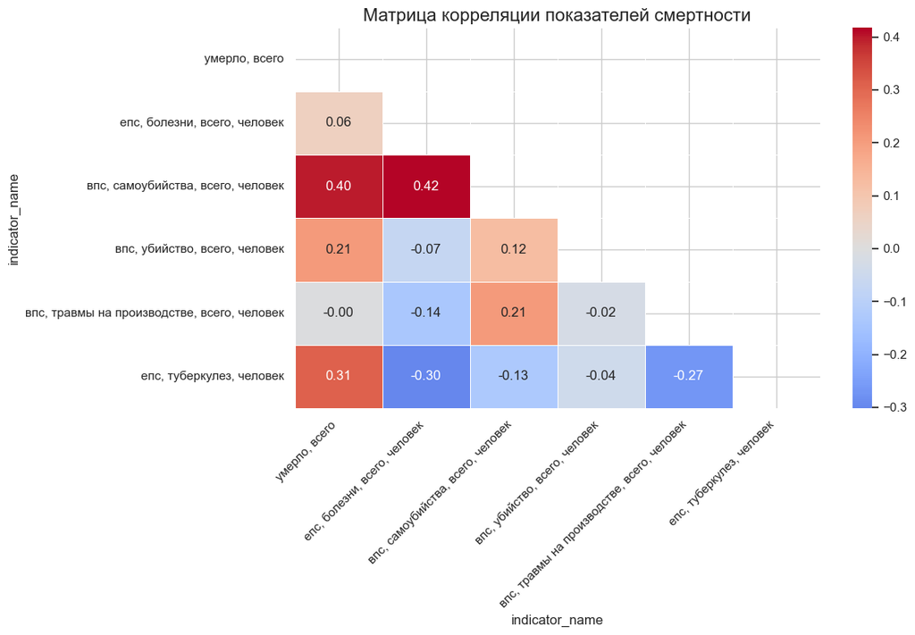

```python
# Матрица корреляции показателей смертности
pivot_data = data.pivot_table(index='year',
                             columns='indicator_name',
                             values='indicator_value',
                             aggfunc='sum')

pivot_data = pivot_data.fillna(0)

selected_columns = [
    'умерло, всего',
    'епс, болезни, всего, человек',
    'впс, самоубийства, всего, человек',
    'впс, убийство, всего, человек',
    'впс, травмы на производстве, всего, человек',
    'епс, туберкулез, человек'
]

corr_data = pivot_data[selected_columns]

# 1. Таблица корреляции
plt.figure(figsize=(12, 8))
corr_matrix = corr_data.corr()
mask = np.triu(np.ones_like(corr_matrix, dtype=bool))
sns.heatmap(corr_matrix,
            annot=True,
            fmt=".2f",
            cmap='coolwarm',
            center=0,
            mask=mask,
            linewidths=.5)
plt.title('Матрица корреляции показателей смертности', fontsize=16)
plt.xticks(rotation=45, ha='right')
plt.tight_layout()
plt.savefig('graphs/Corr.png', dpi=600, bbox_inches='tight')
plt.show()

#print("\nСтатистическая сводка по основным показателям:")
#print(corr_data.describe().round(1))

year_corr = {}
for col in corr_data.columns:
    corr, pval = stats.pearsonr(corr_data.index, corr_data[col])
    year_corr[col] = {'Корреляция': corr, 'p-value': pval}

year_corr_df = pd.DataFrame(year_corr).T
#print("\nКорреляция показателей с годом (тренд):")
#print(year_corr_df.round(3))
```